# Global Baseline Estimate Recommender

Author

Aniss Sahraoui

Published

September 19, 2026

# 1 Overview

The **Global Baseline Estimate** is a simple, non-personalized recommender. It predicts how a person would rate a movie they have not rated from three numbers:

> **Estimate** = overall average  
> + movie’s difference from average  
> + person’s difference from average

A movie that most people rate highly gets a boost, and so does a person who tends to give high ratings. The movie with the highest estimate among those a person has not rated is recommended to them.

In this assignment I write the algorithm as an R function, check it against the course spreadsheet, and apply it to the movie ratings I collected in Week 2.

# 2 The Function

The function takes a table with one row per person and movie, where `rating` is `NA` if the person has not rated the movie. Averages only use the ratings that exist.

```r
global_baseline <- function(ratings) {
  observed <- ratings |> filter(!is.na(rating))

  overall_avg <- mean(observed$rating)

  movie_diff <- observed |>
    group_by(movie) |>
    summarise(movie_diff = mean(rating) - overall_avg)

  person_diff <- observed |>
    group_by(person) |>
    summarise(person_diff = mean(rating) - overall_avg)

  ratings |>
    left_join(movie_diff, by = "movie") |>
    left_join(person_diff, by = "person") |>
    mutate(
      overall_avg = overall_avg,
      estimate = overall_avg + movie_diff + person_diff,
      # the formula can go past the 1-5 scale, so keep the displayed rating inside it
      predicted_rating = pmin(pmax(estimate, 1), 5)
    )
}

recommend <- function(estimates) {
  estimates |>
    filter(is.na(rating)) |>
    group_by(person) |>
    slice_max(estimate, n = 1, with_ties = FALSE) |>
    ungroup() |>
    select(person, recommended_movie = movie, predicted_rating)
}
```

# 3 Checking Against the Spreadsheet

The course spreadsheet `MovieRatings.xlsx` works through one example: *how would Param rate Pitch Perfect 2?* Its answer is **2.28**.

```r
# read_excel() cannot read from a URL, so download the file from GitHub first
spreadsheet_file <- tempfile(fileext = ".xlsx")
download.file("https://raw.githubusercontent.com/AnissSahraoui/DATA607/main/Week3A/MovieRatings.xlsx", spreadsheet_file, mode = "wb", quiet = TRUE)

spreadsheet <- read_excel(spreadsheet_file, sheet = "MovieRatings") |>
  pivot_longer(-Critic, names_to = "movie", values_to = "rating") |>
  rename(person = Critic)

spreadsheet_estimates <- global_baseline(spreadsheet)

spreadsheet_estimates |>
  filter(person == "Param", movie == "PitchPerfect2") |>
  select(person, movie, overall_avg, movie_diff, person_diff, estimate) |>
  mutate(across(where(is.numeric), ~ round(.x, 2)))
```

| person | movie | overall_avg | movie_diff | person_diff | estimate |
| --- | --- | --- | --- | --- | --- |
| Param | PitchPerfect2 | 3.93 | -1.22 | -0.43 | 2.28 |

The function gives the same **2.28** as the spreadsheet: an overall average of 3.93, minus 1.22 because Pitch Perfect 2 is rated below average, minus 0.43 because Param rates below average.

Because the spreadsheet has many unrated movies, it also shows what the recommender is for. Each critic’s recommendation is the unrated movie with the highest estimate:

```r
recommend(spreadsheet_estimates) |>
  mutate(predicted_rating = round(predicted_rating, 2))
```

| person | recommended_movie | predicted_rating |
| --- | --- | --- |
| Burton | Deadpool | 4.51 |
| Dan | CaptainAmerica | 5.00 |
| Dieudonne | JungleBook | 4.63 |
| Matt | Deadpool | 3.76 |
| Mauricio | Deadpool | 4.01 |
| Nathan | Deadpool | 4.51 |
| Param | JungleBook | 3.47 |
| Prashanth | PitchPerfect2 | 3.58 |
| Shipra | Deadpool | 4.51 |
| Steve | Deadpool | 4.51 |
| Vuthy | StarWarsForce | 3.82 |
| Xingjia | Deadpool | 5.00 |

Deadpool is recommended most often, because it has the highest movie average. Critics who rate generously, such as Dan and Xingjia, get higher predicted ratings.

# 4 My Movie Ratings

## 4.1 Loading the data from SQL

My Week 2 ratings are stored in a SQLite database in my GitHub repository. The query returns every person–movie pair, with `NA` where there is no rating.

```r
# Download the Week 2 database from GitHub, then connect to it
db_file <- tempfile(fileext = ".sqlite")
download.file("https://raw.githubusercontent.com/AnissSahraoui/DATA607/main/Week2/movie_ratings.sqlite", db_file, mode = "wb", quiet = TRUE)

con <- dbConnect(SQLite(), db_file)

my_ratings <- dbGetQuery(con, "
  SELECT u.name AS person, m.title AS movie, r.rating
  FROM users u
  CROSS JOIN movies m
  LEFT JOIN ratings r
         ON r.user_id = u.user_id AND r.movie_id = m.movie_id
") |>
  as_tibble()

dbDisconnect(con)

my_ratings |>
  pivot_wider(names_from = movie, values_from = rating)
```

| person | F1 | KPop Demon Hunters | Sinners | Superman | Weapons | Wicked: For Good |
| --- | --- | --- | --- | --- | --- | --- |
| Friend 1 | 5 | 4 | 5 | 5 | 3 | 5 |
| Friend 2 | 5 | 4 | 5 | 5 | 3 | 5 |
| Friend 3 | 5 | 4 | 5 | 5 | 3 | 5 |
| Friend 4 | 5 | 4 | 5 | 5 | 3 | 5 |
| Friend 5 | 5 | 5 | 4 | 5 | 3 | 5 |
| Friend 6 | 5 | 5 | 5 | 4 | 3 | 5 |

## 4.2 Global Baseline on my data

```r
my_estimates <- global_baseline(my_ratings)

my_estimates |> distinct(movie, movie_diff) |> arrange(desc(movie_diff)) |>
  mutate(movie_diff = round(movie_diff, 2))
```

| movie | movie_diff |
| --- | --- |
| F1 | 0.50 |
| Wicked: For Good | 0.50 |
| Sinners | 0.33 |
| Superman | 0.33 |
| KPop Demon Hunters | -0.17 |
| Weapons | -1.50 |

```r
my_estimates |> distinct(person, person_diff)
```

| person | person_diff |
| --- | --- |
| Friend 1 | 0 |
| Friend 2 | 0 |
| Friend 3 | 0 |
| Friend 4 | 0 |
| Friend 5 | 0 |
| Friend 6 | 0 |

```r
sum(is.na(my_ratings$rating))
```

```
[1] 0
```

The overall average is **4.5**. There are two problems:

- **Nothing to recommend.** All six friends rated all six movies, so there are no unrated movies.
- **Every person’s difference is 0.** Each friend’s average rating is exactly 4.5, the same as the overall average, so every estimate is just the movie’s average.

If a new friend joined, the Global Baseline would recommend **F1** or **Wicked: For Good**, the two movies with the highest averages.

# 5 Testing by Hiding Ratings

To still test the recommender on my data, I hide one rating at a time, recalculate everything from the other 35 ratings, and estimate the hidden one. The error is the difference between the estimate and the real rating.

I compare three versions of the formula, to see what each part adds:

- **Overall average** only
- **Overall average + movie’s difference**
- **Full Global Baseline** (overall average + movie’s difference + person’s difference)

```r
hidden <- map_dfr(seq_len(nrow(my_ratings)), \(i) {
  with_one_hidden <- my_ratings
  with_one_hidden$rating[i] <- NA

  est <- global_baseline(with_one_hidden)[i, ]

  tibble(
    person       = my_ratings$person[i],
    movie        = my_ratings$movie[i],
    real_rating  = my_ratings$rating[i],
    overall_only = est$overall_avg,
    with_movie   = est$overall_avg + est$movie_diff,
    full         = est$estimate
  )
})

rmse <- function(estimate, actual) sqrt(mean((estimate - actual)^2))

hidden |>
  summarise(
    `Overall average only`   = rmse(overall_only, real_rating),
    `+ movie's difference`   = rmse(with_movie, real_rating),
    `Full Global Baseline`   = rmse(full, real_rating)
  ) |>
  pivot_longer(everything(), names_to = "Formula", values_to = "RMSE") |>
  mutate(RMSE = round(RMSE, 2))
```

| Formula | RMSE |
| --- | --- |
| Overall average only | 0.79 |
| + movie’s difference | 0.35 |
| Full Global Baseline | 0.41 |

RMSE (root mean squared error) is the typical size of the error, in rating points. Lower is better.

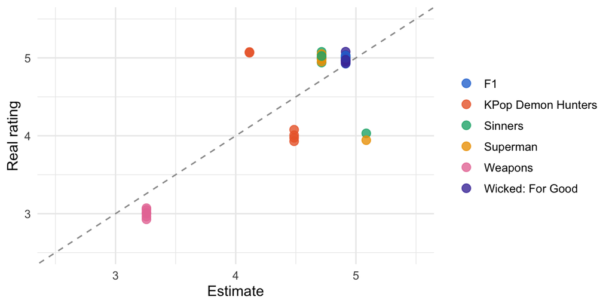

Figure 1: Estimate vs real rating for each hidden rating, using the full Global Baseline.

```r
ggplot(hidden, aes(x = full, y = real_rating, color = movie)) +
  geom_abline(linetype = "dashed", color = "grey60") +
  geom_jitter(width = 0, height = 0.08, size = 3, alpha = 0.8) +
  scale_color_manual(values = c("#2a78d6", "#eb6834", "#1baf7a", "#eda100", "#e87ba4", "#4a3aa7")) +
  scale_x_continuous(limits = c(2.5, 5.5)) +
  scale_y_continuous(limits = c(2.5, 5.5)) +
  labs(x = "Estimate", y = "Real rating", color = NULL) +
  theme_minimal(base_size = 12)
```

Points on the dashed line are perfect estimates.

- **Adding the movie’s difference helps a lot.** The error drops from 0.79 to 0.35. Movies really are rated differently: Weapons is always a 3, and F1 is always a 5.
- **Adding the person’s difference makes it slightly worse** (0.41). My friends all rate the same on average, so there is no real person effect to find. Hiding a rating also moves that person’s average in the wrong direction: hiding one of a friend’s high ratings makes them look like a harsher rater, which pulls the estimate down.
- The biggest errors come from Friends 5 and 6, the two whose ratings differ from the rest.

# 6 Conclusion

- My R function reproduces the course spreadsheet’s result of **2.28** for Param and Pitch Perfect 2.
- On the spreadsheet data, which has many unrated movies, it recommends a movie to each critic, most often Deadpool.
- On my survey data there are no unrated movies, so there is nothing to recommend. A new viewer would be recommended **F1** or **Wicked: For Good**.
- Hiding ratings shows that the movie part of the formula does most of the work on my data. The person part only helps when people rate differently, which my friends do not.

To get a more useful recommender, I would survey more people, especially people who have not seen every movie.